# One-dimensional Models

Tomasz Żółtak

2.07.2018

# Teachers data

First we will work with set of questions used in PISA 2015 Teacher Questionare. Questions regard teacher satisfaction with their occupation. For simplicity we will use data from 3 countries: Germany, Brazil and United Arab Emirates.

```r
(load("teachers.RData"))
```

```
## [1] "teachers"          "teachersMoreInfo"  "teachersVarLabels"
```

```r
summary(droplevels(teachers$CNTRYID))
```

```
##               Brazil              Germany United Arab Emirates
##                 7936                 5548                 6964
```

- Data frame `teachers` contains answers (variables with names starting from “TC026”) and 3 id variables.
  - This survey data has been cleaned. All irrelevant answers to the questions has been replaced with NAs and respondents that didn’t answer to any question have been removed from the dataset.
- Data frame `teachersMoreInfo` contains some additional charactersitics of the respondents.
- Data frame `teachersVarLabels` contains labels of variables in two data frames described above.

So what were teachers asked about?

```r
teachersVarLabels[4:11,]
```

```
##      variable
## 4  TC026Q01NA
## 5  TC026Q02NA
## 6  TC026Q04NA
## 7  TC026Q05NA
## 8  TC026Q06NA
## 9  TC026Q07NA
## 10 TC026Q09NA
## 11 TC026Q10NA
##                                                                       label
## 4     The advantages of being a teacher clearly outweigh the disadvantages.
## 5       If I could decide again, I would still choose to work as a teacher.
## 6                              I regret that I decided to become a teacher.
## 7                                           I enjoy working at this school.
## 8  I wonder whether it would have been better to choose another profession.
## 9                      I would recommend my school as a good place to work.
## 10                       I am satisfied with my performance in this school.
## 11                                  All in all, I am satisfied with my job.
```

All the question were asked using a 4-point Likert scale. How teachers responded to this questions?

```r
summary(teachers[,4:11])
```

```
##              TC026Q01NA               TC026Q02NA
##  Strongly disagree:1717   Strongly disagree:1551
##  Disagree         :4022   Disagree         :3551
##  Agree            :9405   Agree            :8346
##  Strongly agree   :5182   Strongly agree   :6841
##  NA's             : 122   NA's             : 159
##              TC026Q04NA                TC026Q05NA
##  Strongly disagree:10496   Strongly disagree:  456
##  Disagree         : 7220   Disagree         : 1688
##  Agree            : 1913   Agree            :10383
##  Strongly agree   :  672   Strongly agree   : 7773
##  NA's             :  147   NA's             :  148
##              TC026Q06NA               TC026Q07NA
##  Strongly disagree:7046   Strongly disagree:  600
##  Disagree         :6534   Disagree         : 1990
##  Agree            :5237   Agree            :10331
##  Strongly agree   :1487   Strongly agree   : 7404
##  NA's             : 144   NA's             :  123
##              TC026Q09NA                TC026Q10NA
##  Strongly disagree:  186   Strongly disagree: 471
##  Disagree         : 1216   Disagree         :2287
##  Agree            :10842   Agree            :9744
##  Strongly agree   : 8081   Strongly agree   :7838
##  NA's             :  123   NA's             : 108
```

# Simple one-dimensional models

## Simple IRT models with mirt

### One-dimensional SGR IRT model

Let’s use *mirt* first.

Function `mirt()` takes data (as a data frame or matrix) as a first argument and number of factors as a second argument. However we must convert our variables from factor to numeric format.

```r
library(mirt)
teachersNumeric = as.data.frame(lapply(teachers[, 4:11], as.numeric))
# estimate one-dimension Samejima's Graded Response IRT model
mm1Teachers = mirt(teachersNumeric, 1)
```

```
##
Iteration: 1, Log-Lik: -177297.239, Max-Change: 1.22457
Iteration: 2, Log-Lik: -161043.488, Max-Change: 1.26082
Iteration: 3, Log-Lik: -154622.890, Max-Change: 0.61895
Iteration: 4, Log-Lik: -153522.065, Max-Change: 0.27370
Iteration: 5, Log-Lik: -153193.920, Max-Change: 0.20021
Iteration: 6, Log-Lik: -153057.409, Max-Change: 0.09856
Iteration: 7, Log-Lik: -152991.505, Max-Change: 0.07978
Iteration: 8, Log-Lik: -152963.828, Max-Change: 0.04603
Iteration: 9, Log-Lik: -152950.916, Max-Change: 0.04270
Iteration: 10, Log-Lik: -152943.771, Max-Change: 0.02705
Iteration: 11, Log-Lik: -152940.066, Max-Change: 0.02198
Iteration: 12, Log-Lik: -152937.950, Max-Change: 0.01491
Iteration: 13, Log-Lik: -152936.096, Max-Change: 0.00783
Iteration: 14, Log-Lik: -152935.705, Max-Change: 0.00468
Iteration: 15, Log-Lik: -152935.514, Max-Change: 0.00403
Iteration: 16, Log-Lik: -152935.160, Max-Change: 0.00227
Iteration: 17, Log-Lik: -152935.141, Max-Change: 0.00094
Iteration: 18, Log-Lik: -152935.127, Max-Change: 0.00071
Iteration: 19, Log-Lik: -152935.109, Max-Change: 0.00047
Iteration: 20, Log-Lik: -152935.103, Max-Change: 0.00035
Iteration: 21, Log-Lik: -152935.100, Max-Change: 0.00025
Iteration: 22, Log-Lik: -152935.097, Max-Change: 0.00027
Iteration: 23, Log-Lik: -152935.095, Max-Change: 0.00021
Iteration: 24, Log-Lik: -152935.093, Max-Change: 0.00019
Iteration: 25, Log-Lik: -152935.090, Max-Change: 0.00022
Iteration: 26, Log-Lik: -152935.089, Max-Change: 0.00017
Iteration: 27, Log-Lik: -152935.089, Max-Change: 0.00014
Iteration: 28, Log-Lik: -152935.087, Max-Change: 0.00017
Iteration: 29, Log-Lik: -152935.087, Max-Change: 0.00013
Iteration: 30, Log-Lik: -152935.086, Max-Change: 0.00061
Iteration: 31, Log-Lik: -152935.084, Max-Change: 0.00044
Iteration: 32, Log-Lik: -152935.084, Max-Change: 0.00026
Iteration: 33, Log-Lik: -152935.083, Max-Change: 0.00017
Iteration: 34, Log-Lik: -152935.083, Max-Change: 0.00047
Iteration: 35, Log-Lik: -152935.082, Max-Change: 0.00013
Iteration: 36, Log-Lik: -152935.082, Max-Change: 0.00008
```

```r
summary(mm1Teachers)
```

```
##                F1    h2
## TC026Q01NA  0.741 0.549
## TC026Q02NA  0.830 0.690
## TC026Q04NA -0.776 0.602
## TC026Q05NA  0.656 0.431
## TC026Q06NA -0.775 0.600
## TC026Q07NA  0.606 0.367
## TC026Q09NA  0.595 0.355
## TC026Q10NA  0.844 0.713
##
## SS loadings:  4.306
## Proportion Var:  0.538
##
## Factor correlations:
##
##    F1
## F1  1
```

`summary()` method for *mirt* model objects prints a matrix in a EFA-like format:

We can see that:

- As expected, all variables except Q04 and Q06 are positively related to a common factor.
- All relationships are rather strong - with a little exception of Q09 - and quite similar in strength.

We can also inspect questions’ *chararcteristic curves*, ie. plots describing relationship between value of a latent factor and probability of giving each answer.

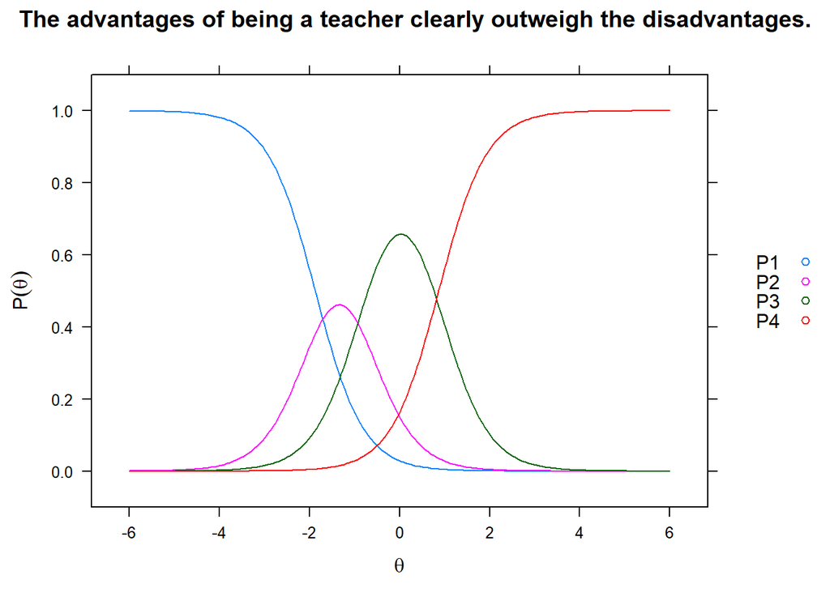

```r
itemplot(mm1Teachers, 1, main = teachersVarLabels$label[4])
```

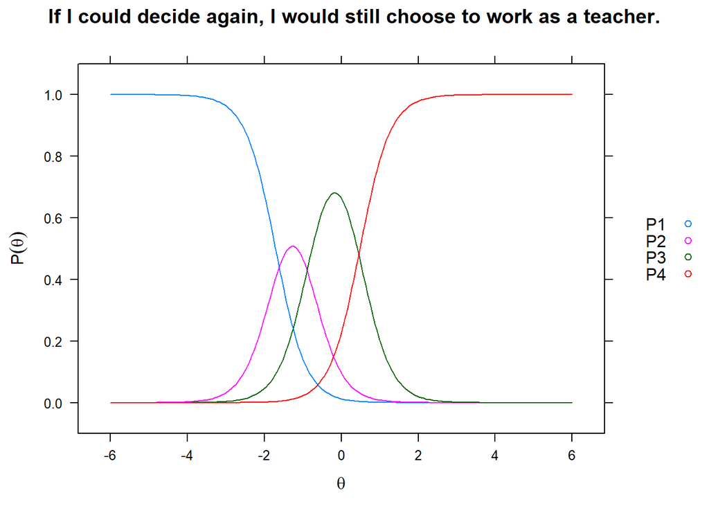

```r
itemplot(mm1Teachers, 2, main = teachersVarLabels$label[5])
```

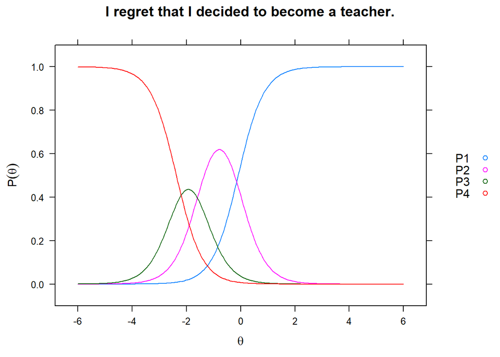

```r
itemplot(mm1Teachers, 3, main = teachersVarLabels$label[6])
```

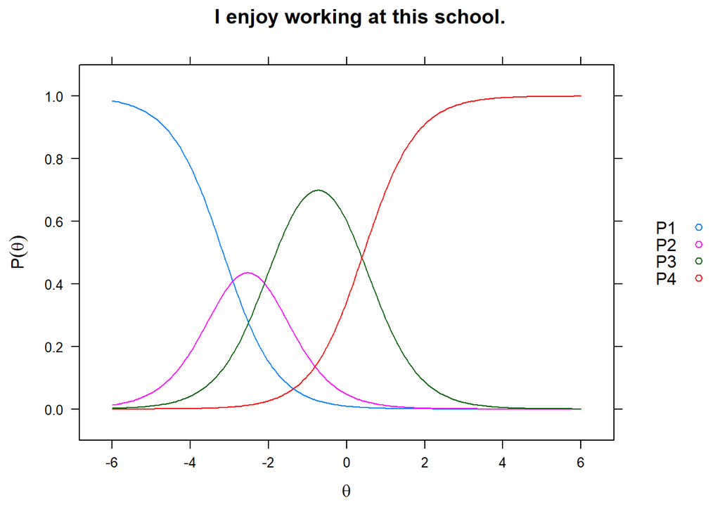

```r
itemplot(mm1Teachers, 4, main = teachersVarLabels$label[7])
```

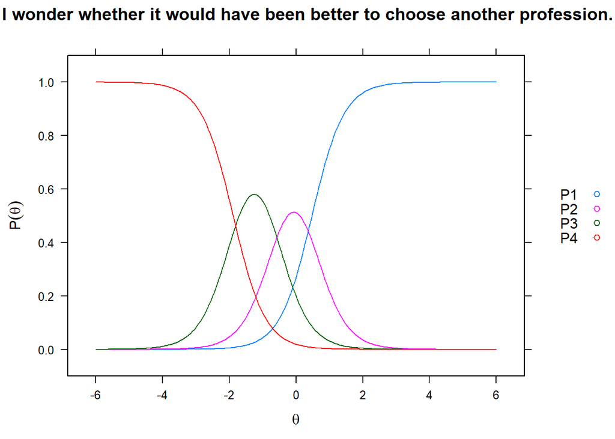

```r
itemplot(mm1Teachers, 5, main = teachersVarLabels$label[8])
```

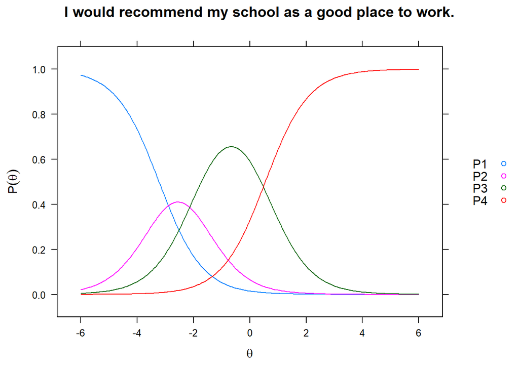

```r
itemplot(mm1Teachers, 6, main = teachersVarLabels$label[9])
```

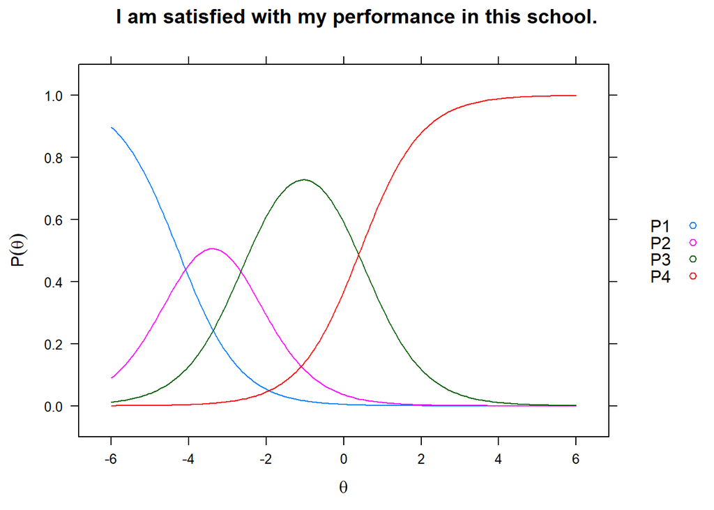

```r
itemplot(mm1Teachers, 7, main = teachersVarLabels$label[10])
```

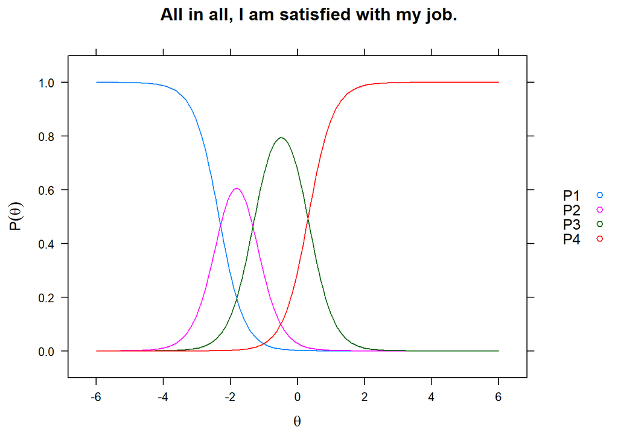

```r
itemplot(mm1Teachers, 8, main = teachersVarLabels$label[11])
```

### How to tell if model is good?

For now let’s assume, that it is good:

- to have at least 3 questions in a scale (this rule comes from CFA approach);
- not to have factor loadings below .5;
- not to have to much variation in (absolute) values of factor loadings.

We can see values of some fit indexes calling `anova()` function, but they won’t be useful without having some other model for a comparison.

```r
anova(mm1Teachers)
```

```
##        AIC     AICc    SABIC       HQ      BIC    logLik
## 1 305934.2 305934.3 306086.1 306017.1 306187.8 -152935.1
```

### Rasch model

Can we assume that relationships between a common factor and all questions have the same strength? Let’s estimate a so-called Rasch model (preciselly: it will be Rasch Partial Credit Model) which introduces such an assumption. However to do this we need to revert two *negatively worded* questions in the dataset.

```r
# reverting negatively worded questions
teachersNumericRev = teachersNumeric
teachersNumericRev$TC026Q04NA = 5 - teachersNumericRev$TC026Q04NA
teachersNumericRev$TC026Q06NA = 5 - teachersNumericRev$TC026Q06NA
# estimate one-dimension Rasch Partial Credit IRT model
mm1rTeachers = mirt(teachersNumericRev, 1, "Rasch")
```

```
##
Iteration: 1, Log-Lik: -160617.827, Max-Change: 1.38071
Iteration: 2, Log-Lik: -156900.932, Max-Change: 0.38049
Iteration: 3, Log-Lik: -156429.758, Max-Change: 0.20794
Iteration: 4, Log-Lik: -156116.139, Max-Change: 0.17573
Iteration: 5, Log-Lik: -155987.126, Max-Change: 0.10321
Iteration: 6, Log-Lik: -155924.629, Max-Change: 0.08154
Iteration: 7, Log-Lik: -155889.465, Max-Change: 0.06725
Iteration: 8, Log-Lik: -155868.765, Max-Change: 0.05758
Iteration: 9, Log-Lik: -155856.183, Max-Change: 0.04731
Iteration: 10, Log-Lik: -155847.961, Max-Change: 0.03958
Iteration: 11, Log-Lik: -155842.382, Max-Change: 0.03278
Iteration: 12, Log-Lik: -155838.472, Max-Change: 0.02557
Iteration: 13, Log-Lik: -155830.459, Max-Change: 0.02371
Iteration: 14, Log-Lik: -155828.996, Max-Change: 0.00692
Iteration: 15, Log-Lik: -155828.680, Max-Change: 0.00667
Iteration: 16, Log-Lik: -155828.076, Max-Change: 0.00578
Iteration: 17, Log-Lik: -155827.968, Max-Change: 0.00272
Iteration: 18, Log-Lik: -155827.930, Max-Change: 0.00271
Iteration: 19, Log-Lik: -155827.891, Max-Change: 0.00212
Iteration: 20, Log-Lik: -155827.838, Max-Change: 0.00274
Iteration: 21, Log-Lik: -155827.829, Max-Change: 0.00039
Iteration: 22, Log-Lik: -155827.828, Max-Change: 0.00028
Iteration: 23, Log-Lik: -155827.827, Max-Change: 0.00024
Iteration: 24, Log-Lik: -155827.826, Max-Change: 0.00022
Iteration: 25, Log-Lik: -155827.826, Max-Change: 0.00023
Iteration: 26, Log-Lik: -155827.825, Max-Change: 0.00021
Iteration: 27, Log-Lik: -155827.825, Max-Change: 0.00020
Iteration: 28, Log-Lik: -155827.825, Max-Change: 0.00114
Iteration: 29, Log-Lik: -155827.822, Max-Change: 0.00017
Iteration: 30, Log-Lik: -155827.822, Max-Change: 0.00015
Iteration: 31, Log-Lik: -155827.821, Max-Change: 0.00015
Iteration: 32, Log-Lik: -155827.821, Max-Change: 0.00014
Iteration: 33, Log-Lik: -155827.821, Max-Change: 0.00014
Iteration: 34, Log-Lik: -155827.821, Max-Change: 0.00020
Iteration: 35, Log-Lik: -155827.820, Max-Change: 0.00013
Iteration: 36, Log-Lik: -155827.820, Max-Change: 0.00018
Iteration: 37, Log-Lik: -155827.820, Max-Change: 0.00014
Iteration: 38, Log-Lik: -155827.820, Max-Change: 0.00014
Iteration: 39, Log-Lik: -155827.820, Max-Change: 0.00014
Iteration: 40, Log-Lik: -155827.820, Max-Change: 0.00028
Iteration: 41, Log-Lik: -155827.820, Max-Change: 0.00015
Iteration: 42, Log-Lik: -155827.819, Max-Change: 0.00023
Iteration: 43, Log-Lik: -155827.819, Max-Change: 0.00014
Iteration: 44, Log-Lik: -155827.819, Max-Change: 0.00018
Iteration: 45, Log-Lik: -155827.819, Max-Change: 0.00013
Iteration: 46, Log-Lik: -155827.819, Max-Change: 0.00030
Iteration: 47, Log-Lik: -155827.819, Max-Change: 0.00014
Iteration: 48, Log-Lik: -155827.819, Max-Change: 0.00027
Iteration: 49, Log-Lik: -155827.818, Max-Change: 0.00013
Iteration: 50, Log-Lik: -155827.818, Max-Change: 0.00024
Iteration: 51, Log-Lik: -155827.818, Max-Change: 0.00012
Iteration: 52, Log-Lik: -155827.818, Max-Change: 0.00011
Iteration: 53, Log-Lik: -155827.818, Max-Change: 0.00013
Iteration: 54, Log-Lik: -155827.818, Max-Change: 0.00011
Iteration: 55, Log-Lik: -155827.818, Max-Change: 0.00087
Iteration: 56, Log-Lik: -155827.817, Max-Change: 0.00007
```

```r
summary(mm1rTeachers)
```

```
##               F1   h2
## TC026Q01NA 0.721 0.52
## TC026Q02NA 0.721 0.52
## TC026Q04NA 0.721 0.52
## TC026Q05NA 0.721 0.52
## TC026Q06NA 0.721 0.52
## TC026Q07NA 0.721 0.52
## TC026Q09NA 0.721 0.52
## TC026Q10NA 0.721 0.52
##
## SS loadings:  4.156
## Proportion Var:  0.52
##
## Factor correlations:
##
##    F1
## F1  1
```

Now we can test whether the previous, more complex model fits data better than the simplier Rasch model (using LR test and some information criteria).

```r
anova(mm1Teachers, mm1rTeachers)
```

```
##
## Model 1: mirt(data = teachersNumericRev, model = 1, itemtype = "Rasch")
## Model 2: mirt(data = teachersNumeric, model = 1)
```

```
##        AIC     AICc    SABIC       HQ      BIC    logLik       X2  df   p
## 1 311705.6 311705.7 311824.3 311770.4 311903.8 -155827.8      NaN NaN NaN
## 2 305934.2 305934.3 306086.1 306017.1 306187.8 -152935.1 5785.469   7   0
```

It looks that Rasch model assumption doesn’t hold.

## The same in lavaan

### Estimation of CCFA with lavaan

We must describe model to *laavan* using specific formula-kind syntax, provided as a string. Also we must make sure that our variables are **ordered** factors (very rarely used R feature). CCFA can be estimated with `cfa()` function.

```r
library(lavaan)
teachersOrdered = as.data.frame(lapply(teachers[, 4:11], ordered))
# estimate one-dimension CCFA model
model = 'F1 =~ TC026Q01NA + TC026Q02NA + TC026Q04NA + TC026Q05NA + TC026Q06NA +
  TC026Q07NA + TC026Q09NA + TC026Q10NA'
# or:
# model = paste0('F1 =~ ', paste0(names(teachersOrdered), collapse = " + "))
mf1Teachers = cfa(model, teachersOrdered)
summary(mf1Teachers, fit.measures = TRUE, standardized = TRUE)
```

```
## lavaan (0.6-1) converged normally after  22 iterations
##
##                                                   Used       Total
##   Number of observations                         19686       20448
##
##   Estimator                                       DWLS      Robust
##   Model Fit Test Statistic                   18660.911   23920.530
##   Degrees of freedom                                20          20
##   P-value (Chi-square)                           0.000       0.000
##   Scaling correction factor                                  0.780
##   Shift parameter                                            5.900
##     for simple second-order correction (Mplus variant)
##
## Model test baseline model:
##
##   Minimum Function Test Statistic           325316.759  179205.463
##   Degrees of freedom                                28          28
##   P-value                                        0.000       0.000
##
## User model versus baseline model:
##
##   Comparative Fit Index (CFI)                    0.943       0.867
##   Tucker-Lewis Index (TLI)                       0.920       0.813
##
##   Robust Comparative Fit Index (CFI)                            NA
##   Robust Tucker-Lewis Index (TLI)                               NA
##
## Root Mean Square Error of Approximation:
##
##   RMSEA                                          0.218       0.246
##   90 Percent Confidence Interval          0.215  0.220       0.244  0.249
##   P-value RMSEA <= 0.05                          0.000       0.000
##
##   Robust RMSEA                                                  NA
##   90 Percent Confidence Interval                                NA     NA
##
## Standardized Root Mean Square Residual:
##
##   SRMR                                           0.134       0.134
##
```

[output cut: 64 more lines]

```
##    .TC026Q07NA        0.415                               0.415    0.415
##    .TC026Q09NA        0.633                               0.633    0.633
##    .TC026Q10NA        0.378                               0.378    0.378
##     F1                0.467    0.006   83.463    0.000    1.000    1.000
##
## Scales y*:
##                    Estimate  Std.Err  z-value  P(>|z|)   Std.lv  Std.all
##     TC026Q01NA        1.000                               1.000    1.000
##     TC026Q02NA        1.000                               1.000    1.000
##     TC026Q04NA        1.000                               1.000    1.000
##     TC026Q05NA        1.000                               1.000    1.000
##     TC026Q06NA        1.000                               1.000    1.000
##     TC026Q07NA        1.000                               1.000    1.000
##     TC026Q09NA        1.000                               1.000    1.000
##     TC026Q10NA        1.000                               1.000    1.000
```

**Let’s note that `cfa()` by default removes missings listwise**, ie. all observations with at least one missing value are excluded from analysis. In `mirt()` all observations are used.

We can compare these results to those from `mirt()`.

```r
data.frame(fact.loadings.lavaan =
             round(standardizedSolution(mf1Teachers)$est.std[1:8], 3),
           fact.loadings.mirt = round(summary(mm1Teachers)$rotF[, 1], 3))
```

[output not shown]

```
##            fact.loadings.lavaan fact.loadings.mirt
## TC026Q01NA                0.683              0.741
## TC026Q02NA                0.780              0.830
## TC026Q04NA               -0.762             -0.776
## TC026Q05NA                0.786              0.656
## TC026Q06NA               -0.778             -0.775
## TC026Q07NA                0.765              0.606
## TC026Q09NA                0.606              0.595
## TC026Q10NA                0.789              0.844
```

Clearly they’re not the same (estimated models are not formally equivalent, because `mirt()` used logistic link function; moreover `cfa()` excluded observations with missings) but qualitatively similar.

### Rasch (probit) model with lavaan

You can estimate Rasch model also within CCFA approach (except that this will be a probit, not a logistic model). To do this with *lavaan* we must fix values of model parameters (remembering about negative wording of two questions):

```r
# estimate one-dimension CCFA Rasch-like model
modelR = 'F1 =~ 1*TC026Q01NA + 1*TC026Q02NA + -1*TC026Q04NA + 1*TC026Q05NA +
  -1*TC026Q06NA + 1*TC026Q07NA + 1*TC026Q09NA + 1*TC026Q10NA'
# or:
# modelR = paste0('F1 =~ ', paste0(c(1, 1, -1, 1, -1, 1, 1, 1), "*",
#                                 names(teachersOrdered), collapse = " + "))
mf1rTeachers = cfa(modelR, teachersOrdered)
summary(mf1rTeachers, fit.measures = TRUE, standardized = TRUE)
```

```
## lavaan (0.6-1) converged normally after   3 iterations
##
##                                                   Used       Total
##   Number of observations                         19686       20448
##
##   Estimator                                       DWLS      Robust
##   Model Fit Test Statistic                   21618.602   20053.386
##   Degrees of freedom                                27          27
##   P-value (Chi-square)                           0.000       0.000
##   Scaling correction factor                                  1.078
##   Shift parameter                                            7.636
##     for simple second-order correction (Mplus variant)
##
## Model test baseline model:
##
##   Minimum Function Test Statistic           325316.759  179205.463
##   Degrees of freedom                                28          28
##   P-value                                        0.000       0.000
##
## User model versus baseline model:
##
##   Comparative Fit Index (CFI)                    0.934       0.888
##   Tucker-Lewis Index (TLI)                       0.931       0.884
##
##   Robust Comparative Fit Index (CFI)                            NA
##   Robust Tucker-Lewis Index (TLI)                               NA
##
## Root Mean Square Error of Approximation:
##
##   RMSEA                                          0.202       0.194
##   90 Percent Confidence Interval          0.199  0.204       0.192  0.196
##   P-value RMSEA <= 0.05                          0.000       0.000
##
##   Robust RMSEA                                                  NA
##   90 Percent Confidence Interval                                NA     NA
##
## Standardized Root Mean Square Residual:
##
##   SRMR                                           0.143       0.143
##
```

[output cut: 64 more lines]

```
##    .TC026Q07NA        0.437                               0.437    0.437
##    .TC026Q09NA        0.437                               0.437    0.437
##    .TC026Q10NA        0.437                               0.437    0.437
##     F1                0.563    0.003  206.577    0.000    1.000    1.000
##
## Scales y*:
##                    Estimate  Std.Err  z-value  P(>|z|)   Std.lv  Std.all
##     TC026Q01NA        1.000                               1.000    1.000
##     TC026Q02NA        1.000                               1.000    1.000
##     TC026Q04NA        1.000                               1.000    1.000
##     TC026Q05NA        1.000                               1.000    1.000
##     TC026Q06NA        1.000                               1.000    1.000
##     TC026Q07NA        1.000                               1.000    1.000
##     TC026Q09NA        1.000                               1.000    1.000
##     TC026Q10NA        1.000                               1.000    1.000
```

We can compare two models with `anova()` function (however result is easy to guess):

```r
anova(mf1rTeachers, mf1Teachers)
```

```
## Scaled Chi Square Difference Test (method = "satorra.2000")
##
##              Df AIC BIC Chisq Chisq diff Df diff Pr(>Chisq)
## mf1Teachers  20         18661
## mf1rTeachers 27         21619     1935.8       7  < 2.2e-16 ***
## ---
## Signif. codes:  0 '***' 0.001 '**' 0.01 '*' 0.05 '.' 0.1 ' ' 1
```

## Estimating factor scores

We know something about our scale, but still don’t have estimates of a latent common factor that we could use in a further analyses. Let’s get them!

### With mirt

```r
teachers$scoresSGRM = fscores(mm1Teachers)[, 1]
```

### With lavaan

Here it’s a little more complicated, because `cfa()` removed cases with missings.

```r
# this will take a while!
teachers$scoresCCFA = NA
teachers$scoresCCFA[-attributes(na.omit(teachersOrdered))$na.action] =
  lavPredict(mf1Teachers)
```

### Simple index

For a comparison let’s construct a simple index. It will be computed as a mean value of observed variables for each respondent (we will use mean instead of sum, because it allows us not to omit cases with missing values).

```r
teachers$simpleIndex = rowMeans(teachersNumericRev, na.rm = TRUE)
```

### A comparison

```r
summary(teachers[, c("simpleIndex", "scoresSGRM", "scoresCCFA")])
```

```
##   simpleIndex      scoresSGRM          scoresCCFA
##  Min.   :1.000   Min.   :-3.306173   Min.   :-2.1677
##  1st Qu.:2.750   1st Qu.:-0.634460   1st Qu.:-0.4387
##  Median :3.125   Median :-0.080730   Median :-0.0527
##  Mean   :3.150   Mean   : 0.000241   Mean   :-0.0095
##  3rd Qu.:3.625   3rd Qu.: 0.657952   3rd Qu.: 0.4411
##  Max.   :4.000   Max.   : 1.732106   Max.   : 1.1151
##                                      NA's   :762
```

```r
round(cor(teachers[, c("simpleIndex", "scoresSGRM", "scoresCCFA")],
          use = "pairwise.complete.obs"), 3)
```

```
##             simpleIndex scoresSGRM scoresCCFA
## simpleIndex       1.000      0.981      0.989
## scoresSGRM        0.981      1.000      0.989
## scoresCCFA        0.989      0.989      1.000
```

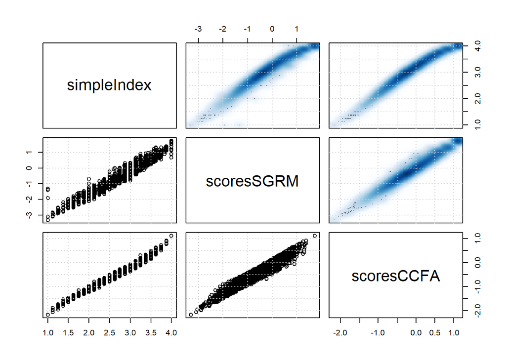

```r
pairs(teachers[, c("simpleIndex", "scoresSGRM", "scoresCCFA")],
      lower.panel = function(x, y) {
        points(x, y)
        grid()},
      upper.panel = function(x, y) {
        smoothScatter(x, y, add = TRUE)
        grid()})
```

It seems that using factor scores couldn’t be much superior to using simply constructed index - as long as questions form a quite-good scale **and a population is homogenous**.

In a simple one-dimensional case scaling is much more about checking whether it is reasonable to treat a set of questions as constituting a scale (being results of a common cause), than about obtainig better estimates of factor scores.

# Multiple groups

## Comparison bettwen countries using scores from single-group models

We have three different countries in our data. First let’s make a comparison using scores derived above.

```r
teachersBr =
  subset(teachers, CNTRYID %in% "Brazil")[, c("simpleIndex", "scoresSGRM",
                                               "scoresCCFA")]
teachersStd = scale(teachers[, c("simpleIndex", "scoresSGRM", "scoresCCFA")],
                    center = sapply(teachersBr, mean, na.rm = TRUE),
                    scale = sapply(teachersBr, sd, na.rm = TRUE))
countryMeans = aggregate(teachersStd,
                         as.list(teachers[, "CNTRYID", drop = FALSE]),
                         mean, na.rm = TRUE)
countryMeans[, -1] = lapply(countryMeans[, -1], round, digits = 2)
names(countryMeans)[-1] = paste0(names(countryMeans)[-1], ".mean")
countrySDs = aggregate(teachersStd,
                       as.list(teachers[, "CNTRYID", drop = FALSE]),
                       sd, na.rm = TRUE)
countrySDs[, -1] = lapply(countrySDs[, -1], round, digits = 2)
names(countrySDs)[-1] = paste0(names(countrySDs)[-1], ".sd")
(countries = merge(countryMeans, countrySDs))
```

```
##                CNTRYID simpleIndex.mean scoresSGRM.mean scoresCCFA.mean
## 1               Brazil             0.00            0.00            0.00
## 2              Germany             0.64            0.73            0.63
## 3 United Arab Emirates             0.23            0.29            0.21
##   simpleIndex.sd scoresSGRM.sd scoresCCFA.sd
## 1           1.00          1.00          1.00
## 2           0.96          1.00          1.03
## 3           0.99          1.02          1.04
```

## Multiple groups models with a measurement invariance

However we may estimate more complex models, in which we will take into account that respondents comes from three potentially different populations. In this models means and standard deviations of a latent trait within each group (except one, that will be a point of reference to the others) will be free estimated model parameters. On the other hand, we will assume, that measurement properties of questions do not vary between countries - this assumption is called measurement invariance (to be precise: *scalar invariance* or *strong factorial invariance*). If we don’t introduce such an assumption, comparing means and variances between groups will make little (or even no) sense.

### Multiple groups model with measurement invariance in mirt

To estimate such a model with *mirt* package we must use `multipleGroup()` function. Compared to `mirt()` function it needs two additional arguments: vector describing grouping and specification of parameters that are to be fixed and parameters that should be freely estimated across groups. Function `multipleGroup()` by default assumes that distribution of latent trait is the same across groups, but questions (items) parameters may vary - just the opposite to what we want to do now. In a code below `invariance = c("free_means", "free_var", "slopes", "intercepts")` tells function to freely estimate means and variances of a latent traits, but to keep parameters describing relationship between latent factor and observed variables fixed (ie. *slopes* and *intercepts*).

```r
mm3Teachers = multipleGroup(teachersNumeric, 1, teachers$CNTRYID,
                            invariance = c("free_means", "free_var",
                                           "slopes", "intercepts"))
```

```
##
Iteration: 1, Log-Lik: -177297.239, Max-Change: 1.16044
Iteration: 2, Log-Lik: -161082.906, Max-Change: 1.21220
Iteration: 3, Log-Lik: -154674.612, Max-Change: 0.54474
Iteration: 4, Log-Lik: -153699.164, Max-Change: 0.30112
Iteration: 5, Log-Lik: -152967.225, Max-Change: 0.21850
Iteration: 6, Log-Lik: -152631.619, Max-Change: 0.14575
Iteration: 7, Log-Lik: -152463.812, Max-Change: 0.11403
Iteration: 8, Log-Lik: -152370.396, Max-Change: 0.10869
Iteration: 9, Log-Lik: -152311.757, Max-Change: 0.08984
Iteration: 10, Log-Lik: -152270.958, Max-Change: 0.07121
Iteration: 11, Log-Lik: -152240.267, Max-Change: 0.05626
Iteration: 12, Log-Lik: -152215.909, Max-Change: 0.04479
Iteration: 13, Log-Lik: -152195.840, Max-Change: 0.03639
Iteration: 14, Log-Lik: -152178.914, Max-Change: 0.02943
Iteration: 15, Log-Lik: -152164.437, Max-Change: 0.02583
Iteration: 16, Log-Lik: -152151.941, Max-Change: 0.02267
Iteration: 17, Log-Lik: -152141.095, Max-Change: 0.02059
Iteration: 18, Log-Lik: -152131.641, Max-Change: 0.01903
Iteration: 19, Log-Lik: -152123.376, Max-Change: 0.01809
Iteration: 20, Log-Lik: -152116.131, Max-Change: 0.01717
Iteration: 21, Log-Lik: -152109.767, Max-Change: 0.01632
Iteration: 22, Log-Lik: -152104.171, Max-Change: 0.01543
Iteration: 23, Log-Lik: -152099.238, Max-Change: 0.01460
Iteration: 24, Log-Lik: -152094.884, Max-Change: 0.01381
Iteration: 25, Log-Lik: -152079.979, Max-Change: 0.02811
Iteration: 26, Log-Lik: -152074.769, Max-Change: 0.00927
Iteration: 27, Log-Lik: -152073.184, Max-Change: 0.00878
Iteration: 28, Log-Lik: -152067.664, Max-Change: 0.01781
Iteration: 29, Log-Lik: -152065.682, Max-Change: 0.00573
Iteration: 30, Log-Lik: -152065.070, Max-Change: 0.00545
Iteration: 31, Log-Lik: -152062.874, Max-Change: 0.01156
Iteration: 32, Log-Lik: -152062.116, Max-Change: 0.00357
Iteration: 33, Log-Lik: -152061.868, Max-Change: 0.00347
Iteration: 34, Log-Lik: -152060.964, Max-Change: 0.00792
Iteration: 35, Log-Lik: -152060.675, Max-Change: 0.00281
Iteration: 36, Log-Lik: -152060.572, Max-Change: 0.00226
Iteration: 37, Log-Lik: -152060.193, Max-Change: 0.00544
Iteration: 38, Log-Lik: -152060.085, Max-Change: 0.00162
Iteration: 39, Log-Lik: -152060.044, Max-Change: 0.00163
```

[output cut: 25 more lines]

```
Iteration: 65, Log-Lik: -152059.736, Max-Change: 0.00012
Iteration: 66, Log-Lik: -152059.737, Max-Change: 0.00015
Iteration: 67, Log-Lik: -152059.737, Max-Change: 0.00017
Iteration: 68, Log-Lik: -152059.739, Max-Change: 0.00015
Iteration: 69, Log-Lik: -152059.739, Max-Change: 0.00018
Iteration: 70, Log-Lik: -152059.740, Max-Change: 0.00014
Iteration: 71, Log-Lik: -152059.739, Max-Change: 0.00020
Iteration: 72, Log-Lik: -152059.741, Max-Change: 0.00013
Iteration: 73, Log-Lik: -152059.740, Max-Change: 0.00020
Iteration: 74, Log-Lik: -152059.741, Max-Change: 0.00013
Iteration: 75, Log-Lik: -152059.741, Max-Change: 0.00014
Iteration: 76, Log-Lik: -152059.742, Max-Change: 0.00011
Iteration: 77, Log-Lik: -152059.742, Max-Change: 0.00013
Iteration: 78, Log-Lik: -152059.743, Max-Change: 0.00011
Iteration: 79, Log-Lik: -152059.743, Max-Change: 0.00010
```

Let’s take a look at the differences between countries:

```r
countryPars = t(sapply(coef(mm3Teachers), function(x) {return(x$GroupPars)}))
countryPars[, 2] = sqrt(countryPars[, 2])
countryPars = round(countryPars, 2)
colnames(countryPars) = c("mean", "sd")
countryPars
```

```
##                      mean   sd
## Brazil               0.00 1.00
## Germany              0.87 1.10
## United Arab Emirates 0.33 1.04
```

Differences between countries estimated as a model parameters became larger. Moreover it appears, that there are also some differences in variation of attitudes within countries (standard deviation of a latent factor in Germany is 10% larger than in Brazil).

### Multiple groups model with measurement invariance in lavaan

```r
mf3Teachers = cfa(model, cbind(teachersOrdered, CNTRY = teachers$CNTRY),
                  group = "CNTRY",
                  group.equal = c("loadings", "intercepts"))
summary(mf3Teachers, fit.measures = TRUE, standardized = TRUE)
```

```
## lavaan (0.6-1) converged normally after  63 iterations
##
##                                                   Used       Total
##   Number of observations per group
##   Brazil                                          7710        7936
##   Germany                                         5322        5548
##   United Arab Emirates                            6654        6964
##
##   Estimator                                       DWLS      Robust
##   Model Fit Test Statistic                   23785.041   29911.822
##   Degrees of freedom                               104         104
##   P-value (Chi-square)                           0.000       0.000
##   Scaling correction factor                                  0.796
##   Shift parameter for each group:
##     Brazil                                                   7.091
##     Germany                                                  4.895
##     United Arab Emirates                                     6.120
##     for simple second-order correction (Mplus variant)
##
## Chi-square for each group:
##
##   Brazil                                     10060.578   12651.512
##   Germany                                     6162.647    7750.284
##   United Arab Emirates                        7561.816    9510.026
##
## Model test baseline model:
##
##   Minimum Function Test Statistic           341066.188  184916.934
##   Degrees of freedom                                84          84
##   P-value                                        0.000       0.000
##
## User model versus baseline model:
##
##   Comparative Fit Index (CFI)                    0.931       0.839
##   Tucker-Lewis Index (TLI)                       0.944       0.870
##
##   Robust Comparative Fit Index (CFI)                            NA
##   Robust Tucker-Lewis Index (TLI)                               NA
##
## Root Mean Square Error of Approximation:
```

[output cut: 233 more lines]

```
##    .TC026Q07NA        0.464                               0.464    0.382
##    .TC026Q09NA        0.560                               0.560    0.562
##    .TC026Q10NA        0.268                               0.268    0.305
##     F1                0.405    0.013   32.250    0.000    1.000    1.000
##
## Scales y*:
##                    Estimate  Std.Err  z-value  P(>|z|)   Std.lv  Std.all
##     TC026Q01NA        1.037    0.014   74.007    0.000    1.037    1.000
##     TC026Q02NA        0.979    0.013   78.141    0.000    0.979    1.000
##     TC026Q04NA        0.969    0.013   76.487    0.000    0.969    1.000
##     TC026Q05NA        0.932    0.013   74.495    0.000    0.932    1.000
##     TC026Q06NA        0.923    0.013   71.482    0.000    0.923    1.000
##     TC026Q07NA        0.908    0.012   74.668    0.000    0.908    1.000
##     TC026Q09NA        1.002    0.014   73.371    0.000    1.002    1.000
##     TC026Q10NA        1.067    0.014   78.296    0.000    1.067    1.000
```

To compare groups we must do some additional operations:

```r
groupMeans = subset(parameterEstimates(mf3Teachers),
                    lhs %in% "F1" & op %in% c( "~1"))$est
groupVars = subset(parameterEstimates(mf3Teachers),
                    lhs %in% "F1" & op %in% c( "~~"))$est
groupMeans  = groupMeans  / sqrt(groupVars[1])
groupVars = groupVars / groupVars[1]
data.frame(country = c("Brazil", "Germany", "United Arab Emirates"),
           mean = round(groupMeans, 2),
           sd = round(groupVars^0.5, 2))
```

```
##                country mean   sd
## 1               Brazil 0.00 1.00
## 2              Germany 0.79 1.19
## 3 United Arab Emirates 0.23 1.04
```

### Does this hold with factor scores?

```r
teachers$scoresSGRMmg = fscores(mm3Teachers)[, 1]
teachers$scoresCCFAmg = NA
temp = lavPredict(mf3Teachers)
teachers$scoresCCFAmg[-union(attributes(na.omit(teachersOrdered))$na.action,
                             which(!(teachers$CNTRYID %in% "Brazil")))] =
  temp[[1]]
teachers$scoresCCFAmg[-union(attributes(na.omit(teachersOrdered))$na.action,
                             which(!(teachers$CNTRYID %in% "Germany")))] =
  temp[[2]]
teachers$scoresCCFAmg[-union(attributes(na.omit(teachersOrdered))$na.action,
                             which(!(teachers$CNTRYID %in% "United Arab Emirates")))] =
  temp[[3]]

teachersBr =
  subset(teachers, CNTRYID %in% "Brazil")[, c("scoresSGRMmg", "scoresCCFAmg")]
teachersStdMg = scale(teachers[, c("scoresSGRMmg", "scoresCCFAmg")],
                      center = sapply(teachersBr, mean, na.rm = TRUE),
                      scale = sapply(teachersBr, sd, na.rm = TRUE))
countryMeansMg = aggregate(teachersStdMg,
                           as.list(teachers[, "CNTRYID", drop = FALSE]),
                           mean, na.rm = TRUE)
countryMeansMg[, -1] = lapply(countryMeansMg[, -1], round, digits = 2)
names(countryMeansMg)[-1] = paste0(names(countryMeansMg)[-1], ".mean")
countrySDsMg = aggregate(teachersStdMg,
                         as.list(teachers[, "CNTRYID", drop = FALSE]),
                         sd, na.rm = TRUE)
countrySDsMg[, -1] = lapply(countrySDsMg[, -1], round, digits = 2)
names(countrySDsMg)[-1] = paste0(names(countrySDsMg)[-1], ".sd")
(countriesMg = merge(countryMeansMg, countrySDsMg))
```

```
##                CNTRYID scoresSGRMmg.mean scoresCCFAmg.mean scoresSGRMmg.sd
## 1               Brazil              0.00              0.00            1.00
## 2              Germany              0.94              0.09            1.08
## 3 United Arab Emirates              0.36             -0.01            1.04
##   scoresCCFAmg.sd
## 1            1.00
## 2            1.15
## 3            1.06
```

Factor scores from *mirt* shows even greater differences than model parameters.

**Factor scores from multigroup model extracted with *lavaan* can’t be trusted!**

### Multiple groups with model invariance - summary

- **If in your analysis differences between groups are of primary interest, the best choice is to estimate multigroup model and to draw conclusions looking at model parameters describing distribution of a laten trait.**
- If you need to estimate factor scores to be used in further analysis, you must choose:
  - Scores from one-group model will underestimate differences between groups.
  - Scores from multiple group model will overestimate differences between groups.
  - At least for now, you should not use factor scores from multigroup model extracted with *lavaan*.

# Distractions of unidimensionality

As we have seen, unidimensional model applied to this set of 8 questions doesn’t fit data very well. We can look for some more complicated model specifications that will improve the fit.

Let’s look at the first solution. How to determine, which (pairs/subsets of) questions are causing problems?

## Using modification indices to detect problems

```r
modind = modificationIndices(mf1Teachers)
modind[order(-modind$mi), ]
```

```
##           lhs op        rhs        mi    epc sepc.lv sepc.all sepc.nox
## 78 TC026Q05NA ~~ TC026Q07NA 10610.631  0.547   0.547    1.372    1.372
## 73 TC026Q04NA ~~ TC026Q06NA  4208.644  0.342   0.342    0.840    0.840
## 81 TC026Q06NA ~~ TC026Q07NA  2422.371  0.396   0.396    0.977    0.977
## 86 TC026Q09NA ~~ TC026Q10NA  1921.539  0.260   0.260    0.531    0.531
## 77 TC026Q05NA ~~ TC026Q06NA  1870.956  0.341   0.341    0.878    0.878
## 74 TC026Q04NA ~~ TC026Q07NA  1758.005  0.351   0.351    0.842    0.842
## 69 TC026Q02NA ~~ TC026Q07NA  1349.665 -0.285  -0.285   -0.706   -0.706
## 72 TC026Q04NA ~~ TC026Q05NA  1311.029  0.289   0.289    0.721    0.721
## 59 TC026Q01NA ~~ TC026Q02NA   833.858  0.164   0.164    0.358    0.358
## 63 TC026Q01NA ~~ TC026Q07NA   827.948 -0.226  -0.226   -0.481   -0.481
## 67 TC026Q02NA ~~ TC026Q05NA   745.027 -0.199  -0.199   -0.515   -0.515
## 61 TC026Q01NA ~~ TC026Q05NA   654.933 -0.199  -0.199   -0.440   -0.440
## 82 TC026Q06NA ~~ TC026Q09NA   599.770  0.197   0.197    0.394    0.394
## 68 TC026Q02NA ~~ TC026Q06NA   545.461 -0.128  -0.128   -0.326   -0.326
## 75 TC026Q04NA ~~ TC026Q09NA   482.803  0.184   0.184    0.358    0.358
## 65 TC026Q01NA ~~ TC026Q10NA   418.431  0.122   0.122    0.272    0.272
## 70 TC026Q02NA ~~ TC026Q09NA   321.170 -0.143  -0.143   -0.287   -0.287
## 80 TC026Q05NA ~~ TC026Q10NA   250.454 -0.109  -0.109   -0.286   -0.286
## 76 TC026Q04NA ~~ TC026Q10NA   206.963  0.096   0.096    0.240    0.240
## 83 TC026Q06NA ~~ TC026Q10NA   185.256  0.087   0.087    0.226    0.226
## 85 TC026Q07NA ~~ TC026Q10NA   147.326 -0.082  -0.082   -0.208   -0.208
## 66 TC026Q02NA ~~ TC026Q04NA   127.267 -0.065  -0.065   -0.161   -0.161
## 84 TC026Q07NA ~~ TC026Q09NA   109.332  0.072   0.072    0.140    0.140
## 64 TC026Q01NA ~~ TC026Q09NA    66.512 -0.064  -0.064   -0.110   -0.110
## 60 TC026Q01NA ~~ TC026Q04NA    14.806  0.025   0.025    0.054    0.054
## 71 TC026Q02NA ~~ TC026Q10NA     7.470 -0.017  -0.017   -0.044   -0.044
## 62 TC026Q01NA ~~ TC026Q06NA     2.895  0.011   0.011    0.023    0.023
## 79 TC026Q05NA ~~ TC026Q09NA     2.649 -0.012  -0.012   -0.024   -0.024
```

We can see, that the most important problem is relationship of Q05 with Q07.

```r
teachersVarLabels[grep("Q0[57]", teachersVarLabels$variable), ]
```

```
##     variable                                                label
## 7 TC026Q05NA                      I enjoy working at this school.
## 9 TC026Q07NA I would recommend my school as a good place to work.
```

These are two questions with the strongest reference to a climate in the specific place where respondent works.

Because problem involves only two questions, adding to a model correlation between observed variables’ errors seems to be a good solution within CCFA approach.

```r
modelCe1 = '
F1 =~ TC026Q01NA + TC026Q02NA + TC026Q04NA + TC026Q05NA + TC026Q06NA +
  TC026Q07NA + TC026Q09NA + TC026Q10NA
TC026Q05NA ~~ TC026Q07NA'
mfCe1Teachers = cfa(modelCe1, teachersOrdered)
summary(mfCe1Teachers, fit.measures = TRUE, standardized = TRUE)
```

```
## lavaan (0.6-1) converged normally after  21 iterations
##
##                                                   Used       Total
##   Number of observations                         19686       20448
##
##   Estimator                                       DWLS      Robust
##   Model Fit Test Statistic                    8165.152   12457.466
##   Degrees of freedom                                19          19
##   P-value (Chi-square)                           0.000       0.000
##   Scaling correction factor                                  0.656
##   Shift parameter                                            4.823
##     for simple second-order correction (Mplus variant)
##
## Model test baseline model:
##
##   Minimum Function Test Statistic           325316.759  179205.463
##   Degrees of freedom                                28          28
##   P-value                                        0.000       0.000
##
## User model versus baseline model:
##
##   Comparative Fit Index (CFI)                    0.975       0.931
##   Tucker-Lewis Index (TLI)                       0.963       0.898
##
##   Robust Comparative Fit Index (CFI)                            NA
##   Robust Tucker-Lewis Index (TLI)                               NA
##
## Root Mean Square Error of Approximation:
##
##   RMSEA                                          0.148       0.182
##   90 Percent Confidence Interval          0.145  0.150       0.180  0.185
##   P-value RMSEA <= 0.05                          0.000       0.000
##
##   Robust RMSEA                                                  NA
##   90 Percent Confidence Interval                                NA     NA
##
## Standardized Root Mean Square Residual:
##
##   SRMR                                           0.091       0.091
##
```

[output cut: 69 more lines]

```
##    .TC026Q07NA        0.708                               0.708    0.708
##    .TC026Q09NA        0.604                               0.604    0.604
##    .TC026Q10NA        0.319                               0.319    0.319
##     F1                0.497    0.006   86.729    0.000    1.000    1.000
##
## Scales y*:
##                    Estimate  Std.Err  z-value  P(>|z|)   Std.lv  Std.all
##     TC026Q01NA        1.000                               1.000    1.000
##     TC026Q02NA        1.000                               1.000    1.000
##     TC026Q04NA        1.000                               1.000    1.000
##     TC026Q05NA        1.000                               1.000    1.000
##     TC026Q06NA        1.000                               1.000    1.000
##     TC026Q07NA        1.000                               1.000    1.000
##     TC026Q09NA        1.000                               1.000    1.000
##     TC026Q10NA        1.000                               1.000    1.000
```

We can see that it considerably improved fit of a model. What can we improve further?

```r
modind = modificationIndices(mfCe1Teachers)
modind[order(-modind$mi), ]
```

```
##           lhs op        rhs       mi    epc sepc.lv sepc.all sepc.nox
## 74 TC026Q04NA ~~ TC026Q06NA 2954.025  0.300   0.300    0.800    0.800
## 86 TC026Q09NA ~~ TC026Q10NA 1217.788  0.220   0.220    0.501    0.501
## 84 TC026Q07NA ~~ TC026Q09NA 1158.798  0.229   0.229    0.349    0.349
## 82 TC026Q06NA ~~ TC026Q09NA  881.459  0.243   0.243    0.520    0.520
## 76 TC026Q04NA ~~ TC026Q09NA  706.776  0.227   0.227    0.467    0.467
## 83 TC026Q06NA ~~ TC026Q10NA  630.835  0.168   0.168    0.495    0.495
## 77 TC026Q04NA ~~ TC026Q10NA  603.878  0.169   0.169    0.481    0.481
## 81 TC026Q06NA ~~ TC026Q07NA  592.164  0.197   0.197    0.389    0.389
## 71 TC026Q02NA ~~ TC026Q09NA  537.023 -0.188  -0.188   -0.405   -0.405
## 85 TC026Q07NA ~~ TC026Q10NA  483.252  0.152   0.152    0.319    0.319
## 60 TC026Q01NA ~~ TC026Q02NA  417.683  0.120   0.120    0.282    0.282
## 75 TC026Q04NA ~~ TC026Q07NA  353.686  0.158   0.158    0.301    0.301
## 78 TC026Q05NA ~~ TC026Q06NA  351.559  0.148   0.148    0.301    0.301
## 79 TC026Q05NA ~~ TC026Q09NA  336.528  0.133   0.133    0.208    0.208
## 80 TC026Q05NA ~~ TC026Q10NA  242.522  0.108   0.108    0.234    0.234
## 72 TC026Q02NA ~~ TC026Q10NA  221.056 -0.097  -0.097   -0.286   -0.286
## 65 TC026Q01NA ~~ TC026Q09NA  164.789 -0.102  -0.102   -0.185   -0.185
## 73 TC026Q04NA ~~ TC026Q05NA  156.062  0.100   0.100    0.195    0.195
## 69 TC026Q02NA ~~ TC026Q06NA  142.647 -0.069  -0.069   -0.191   -0.191
## 61 TC026Q01NA ~~ TC026Q04NA  104.720  0.069   0.069    0.156    0.156
## 70 TC026Q02NA ~~ TC026Q07NA  104.453 -0.080  -0.080   -0.159   -0.159
## 66 TC026Q01NA ~~ TC026Q10NA   99.566  0.062   0.062    0.155    0.155
## 63 TC026Q01NA ~~ TC026Q06NA   81.879  0.058   0.058    0.137    0.137
## 64 TC026Q01NA ~~ TC026Q07NA   46.711 -0.054  -0.054   -0.090   -0.090
## 62 TC026Q01NA ~~ TC026Q05NA   18.955 -0.034  -0.034   -0.058   -0.058
## 67 TC026Q02NA ~~ TC026Q04NA    2.941 -0.010  -0.010   -0.028   -0.028
## 68 TC026Q02NA ~~ TC026Q05NA    0.393  0.005   0.005    0.009    0.009
```

```r
teachersVarLabels[grep("Q0[46]", teachersVarLabels$variable), ]
```

```
##     variable
## 6 TC026Q04NA
## 8 TC026Q06NA
##                                                                      label
## 6                             I regret that I decided to become a teacher.
## 8 I wonder whether it would have been better to choose another profession.
```

```r
modelCe2 = '
F1 =~ TC026Q01NA + TC026Q02NA + TC026Q04NA + TC026Q05NA + TC026Q06NA +
  TC026Q07NA + TC026Q09NA + TC026Q10NA
TC026Q05NA ~~ TC026Q07NA
TC026Q04NA ~~ TC026Q06NA'
mfCe2Teachers = cfa(modelCe2, teachersOrdered)
summary(mfCe2Teachers, fit.measures = TRUE, standardized = TRUE)
```

```
## lavaan (0.6-1) converged normally after  21 iterations
##
##                                                   Used       Total
##   Number of observations                         19686       20448
##
##   Estimator                                       DWLS      Robust
##   Model Fit Test Statistic                    5263.388    8911.421
##   Degrees of freedom                                18          18
##   P-value (Chi-square)                           0.000       0.000
##   Scaling correction factor                                  0.591
##   Shift parameter                                            4.148
##     for simple second-order correction (Mplus variant)
##
## Model test baseline model:
##
##   Minimum Function Test Statistic           325316.759  179205.463
##   Degrees of freedom                                28          28
##   P-value                                        0.000       0.000
##
## User model versus baseline model:
##
##   Comparative Fit Index (CFI)                    0.984       0.950
##   Tucker-Lewis Index (TLI)                       0.975       0.923
##
##   Robust Comparative Fit Index (CFI)                            NA
##   Robust Tucker-Lewis Index (TLI)                               NA
##
## Root Mean Square Error of Approximation:
##
##   RMSEA                                          0.122       0.158
##   90 Percent Confidence Interval          0.119  0.124       0.156  0.161
##   P-value RMSEA <= 0.05                          0.000       0.000
##
##   Robust RMSEA                                                  NA
##   90 Percent Confidence Interval                                NA     NA
##
## Standardized Root Mean Square Residual:
##
##   SRMR                                           0.075       0.075
##
```

[output cut: 71 more lines]

```
##    .TC026Q07NA        0.693                               0.693    0.693
##    .TC026Q09NA        0.589                               0.589    0.589
##    .TC026Q10NA        0.281                               0.281    0.281
##     F1                0.519    0.006   87.897    0.000    1.000    1.000
##
## Scales y*:
##                    Estimate  Std.Err  z-value  P(>|z|)   Std.lv  Std.all
##     TC026Q01NA        1.000                               1.000    1.000
##     TC026Q02NA        1.000                               1.000    1.000
##     TC026Q04NA        1.000                               1.000    1.000
##     TC026Q05NA        1.000                               1.000    1.000
##     TC026Q06NA        1.000                               1.000    1.000
##     TC026Q07NA        1.000                               1.000    1.000
##     TC026Q09NA        1.000                               1.000    1.000
##     TC026Q10NA        1.000                               1.000    1.000
```

## Dealing with correlated errors in mirt

In *mirt* we don’t have convinient tools to detect what pairs of questions are correlated independently of relationship with a common factor. However if we detected this otherwise, we can use bifactor model specification that describes such correlations. It is done in a different way than we have done above, by introducing additional, so-called specific factors (independent of each other and of a general factor) to a model. To do it with *mirt* we should use `bfactor()` function, in a second argument describing attribution of questions (items) to specific factors (with `NA` meaning no attribution to any of this factors).

```r
# this model is 3-dimensional, so it is more demanding computationally
# we will decrease default convergence threshold to speed up computations
mmBfTeachers = bfactor(teachersNumeric, c(NA, NA, 1, 2, 1, 2, NA, NA), TOL = 0.001)
```

```
##
Iteration: 1, Log-Lik: -177239.550, Max-Change: 2.42156
Iteration: 2, Log-Lik: -165024.932, Max-Change: 1.69305
Iteration: 3, Log-Lik: -153712.397, Max-Change: 0.77091
Iteration: 4, Log-Lik: -151589.356, Max-Change: 0.65311
Iteration: 5, Log-Lik: -150464.205, Max-Change: 0.50843
Iteration: 6, Log-Lik: -149596.241, Max-Change: 0.61250
Iteration: 7, Log-Lik: -149055.460, Max-Change: 0.48844
Iteration: 8, Log-Lik: -148762.548, Max-Change: 0.44309
Iteration: 9, Log-Lik: -148616.144, Max-Change: 0.44282
Iteration: 10, Log-Lik: -148532.167, Max-Change: 0.37591
Iteration: 11, Log-Lik: -148484.167, Max-Change: 0.09110
Iteration: 12, Log-Lik: -148467.304, Max-Change: 0.06330
Iteration: 13, Log-Lik: -148459.015, Max-Change: 0.04919
Iteration: 14, Log-Lik: -148453.029, Max-Change: 0.06305
Iteration: 15, Log-Lik: -148449.401, Max-Change: 0.02459
Iteration: 16, Log-Lik: -148447.492, Max-Change: 0.02260
Iteration: 17, Log-Lik: -148445.971, Max-Change: 0.02471
Iteration: 18, Log-Lik: -148444.898, Max-Change: 0.01716
Iteration: 19, Log-Lik: -148443.259, Max-Change: 0.00399
Iteration: 20, Log-Lik: -148442.927, Max-Change: 0.00752
Iteration: 21, Log-Lik: -148442.664, Max-Change: 0.00392
Iteration: 22, Log-Lik: -148442.240, Max-Change: 0.00597
Iteration: 23, Log-Lik: -148442.131, Max-Change: 0.00598
Iteration: 24, Log-Lik: -148442.015, Max-Change: 0.00206
Iteration: 25, Log-Lik: -148441.951, Max-Change: 0.00301
Iteration: 26, Log-Lik: -148441.881, Max-Change: 0.00155
Iteration: 27, Log-Lik: -148441.823, Max-Change: 0.00695
Iteration: 28, Log-Lik: -148441.739, Max-Change: 0.00153
Iteration: 29, Log-Lik: -148441.701, Max-Change: 0.00129
Iteration: 30, Log-Lik: -148441.671, Max-Change: 0.00281
Iteration: 31, Log-Lik: -148441.631, Max-Change: 0.00213
Iteration: 32, Log-Lik: -148441.597, Max-Change: 0.00078
```

```r
summary(mmBfTeachers)
```

```
##                 G    S1    S2    h2
## TC026Q01NA  0.760 0.000 0.000 0.578
## TC026Q02NA  0.823 0.000 0.000 0.678
## TC026Q04NA -0.711 0.535 0.000 0.792
## TC026Q05NA  0.603 0.000 0.692 0.842
## TC026Q06NA -0.727 0.497 0.000 0.775
## TC026Q07NA  0.552 0.000 0.710 0.809
## TC026Q09NA  0.608 0.000 0.000 0.369
## TC026Q10NA  0.863 0.000 0.000 0.746
##
## SS loadings:  4.073 0.533 0.983
## Proportion Var:  0.509 0.067 0.123
##
## Factor correlations:
##
##    G S1 S2
## G  1  0  0
## S1 0  1  0
## S2 0  0  1
```

## Bi-factor model in lavaan

We can’t estimate a bi-factor model like this above within CCFA approach due to noidentification problem. Generally there should be at least three observed variables connected with each latent factor to enable model identification.

A bi-factor model in which we assume that specific factors desribes question’s reference to a more general sattisfaction or to a sattisfaction with a particular school where teacher works, can be estimated with CCFA. Writing model specification we must add lines describing indpendence of the latent factors.

```r
modelBf = '
F1 =~ TC026Q01NA + TC026Q02NA + TC026Q04NA + TC026Q05NA + TC026Q06NA +
  TC026Q07NA + TC026Q09NA + TC026Q10NA
F2 =~ TC026Q01NA + TC026Q02NA + TC026Q04NA + TC026Q06NA
F3 =~ TC026Q05NA + TC026Q07NA + TC026Q09NA + TC026Q10NA
F1 ~~ 0*F2
F1 ~~ 0*F3
F2 ~~ 0*F3'
mfBfTeachers = cfa(modelBf, teachersOrdered)
summary(mfBfTeachers, fit.measures = TRUE, standardized = TRUE)
```

```
## lavaan (0.6-1) converged normally after  66 iterations
##
##                                                   Used       Total
##   Number of observations                         19686       20448
##
##   Estimator                                       DWLS      Robust
##   Model Fit Test Statistic                     868.945    2202.367
##   Degrees of freedom                                12          12
##   P-value (Chi-square)                           0.000       0.000
##   Scaling correction factor                                  0.395
##   Shift parameter                                            1.384
##     for simple second-order correction (Mplus variant)
##
## Model test baseline model:
##
##   Minimum Function Test Statistic           325316.759  179205.463
##   Degrees of freedom                                28          28
##   P-value                                        0.000       0.000
##
## User model versus baseline model:
##
##   Comparative Fit Index (CFI)                    0.997       0.988
##   Tucker-Lewis Index (TLI)                       0.994       0.971
##
##   Robust Comparative Fit Index (CFI)                            NA
##   Robust Tucker-Lewis Index (TLI)                               NA
##
## Root Mean Square Error of Approximation:
##
##   RMSEA                                          0.060       0.096
##   90 Percent Confidence Interval          0.057  0.064       0.093  0.100
##   P-value RMSEA <= 0.05                          0.000       0.000
##
##   Robust RMSEA                                                  NA
##   90 Percent Confidence Interval                                NA     NA
##
## Standardized Root Mean Square Residual:
##
##   SRMR                                           0.028       0.028
##
```

[output cut: 86 more lines]

```
##    .TC026Q10NA        0.043                               0.043    0.043
##     F1                0.408    0.007   56.100    0.000    1.000    1.000
##     F2                0.096    0.005   20.669    0.000    1.000    1.000
##     F3                0.239    0.014   17.009    0.000    1.000    1.000
##
## Scales y*:
##                    Estimate  Std.Err  z-value  P(>|z|)   Std.lv  Std.all
##     TC026Q01NA        1.000                               1.000    1.000
##     TC026Q02NA        1.000                               1.000    1.000
##     TC026Q04NA        1.000                               1.000    1.000
##     TC026Q05NA        1.000                               1.000    1.000
##     TC026Q06NA        1.000                               1.000    1.000
##     TC026Q07NA        1.000                               1.000    1.000
##     TC026Q09NA        1.000                               1.000    1.000
##     TC026Q10NA        1.000                               1.000    1.000
```

We can see that such a model fits data much better than our base unidimensional model (however we can notice, that Q10 appears not to be related to the second specific factor). It also fits data better than a model with two residual correlations added. However we can’t directly test fit of this bi-factor model and a model with residual correlations (for example with `nova()` function), because the models are not nested.

However we should note that we encountered some **problems with estimation**. Because of that, results can’t be fully trusted. Generaly we have too few observed variables to assure stable estimation of a model with 3 latent factors within CCFA approach. This won’t be so serious problem within IRT approach:

```r
# this model is 3-dimensional, so it is more demanding computationally
# we will decrease default convergence threshold to speed up computations
mmBf2Teachers = bfactor(teachersNumeric, c(1, 1, 1, 2, 1, 2, 2, 2), TOL = 0.001)
```

```
##
Iteration: 1, Log-Lik: -179509.484, Max-Change: 5.45361
Iteration: 2, Log-Lik: -164642.640, Max-Change: 5.20500
Iteration: 3, Log-Lik: -152280.970, Max-Change: 0.67404
Iteration: 4, Log-Lik: -149795.875, Max-Change: 0.39223
Iteration: 5, Log-Lik: -148770.918, Max-Change: 0.34488
Iteration: 6, Log-Lik: -148249.869, Max-Change: 0.43922
Iteration: 7, Log-Lik: -147912.883, Max-Change: 0.39186
Iteration: 8, Log-Lik: -147724.585, Max-Change: 0.23516
Iteration: 9, Log-Lik: -147636.463, Max-Change: 0.20707
Iteration: 10, Log-Lik: -147561.834, Max-Change: 0.19399
Iteration: 11, Log-Lik: -147490.806, Max-Change: 0.17678
Iteration: 12, Log-Lik: -147417.938, Max-Change: 0.22981
Iteration: 13, Log-Lik: -147345.599, Max-Change: 0.19127
Iteration: 14, Log-Lik: -147275.877, Max-Change: 0.15875
Iteration: 15, Log-Lik: -147207.694, Max-Change: 0.19531
Iteration: 16, Log-Lik: -147145.579, Max-Change: 0.13555
Iteration: 17, Log-Lik: -147103.801, Max-Change: 0.10362
Iteration: 18, Log-Lik: -147069.290, Max-Change: 0.09213
Iteration: 19, Log-Lik: -147036.753, Max-Change: 0.08948
Iteration: 20, Log-Lik: -147009.232, Max-Change: 0.09005
Iteration: 21, Log-Lik: -146987.034, Max-Change: 0.07961
Iteration: 22, Log-Lik: -146967.426, Max-Change: 0.06121
Iteration: 23, Log-Lik: -146954.036, Max-Change: 0.04726
Iteration: 24, Log-Lik: -146939.041, Max-Change: 0.04856
Iteration: 25, Log-Lik: -146928.698, Max-Change: 0.04390
Iteration: 26, Log-Lik: -146919.406, Max-Change: 0.04163
Iteration: 27, Log-Lik: -146910.952, Max-Change: 0.04370
Iteration: 28, Log-Lik: -146902.581, Max-Change: 0.03638
Iteration: 29, Log-Lik: -146895.488, Max-Change: 0.05458
Iteration: 30, Log-Lik: -146888.836, Max-Change: 0.04764
Iteration: 31, Log-Lik: -146882.663, Max-Change: 0.03582
Iteration: 32, Log-Lik: -146876.359, Max-Change: 0.04195
Iteration: 33, Log-Lik: -146870.431, Max-Change: 0.03279
Iteration: 34, Log-Lik: -146865.049, Max-Change: 0.02796
Iteration: 35, Log-Lik: -146859.992, Max-Change: 0.04035
Iteration: 36, Log-Lik: -146854.967, Max-Change: 0.03836
Iteration: 37, Log-Lik: -146850.655, Max-Change: 0.03407
Iteration: 38, Log-Lik: -146846.263, Max-Change: 0.03585
Iteration: 39, Log-Lik: -146842.290, Max-Change: 0.03427
```

[output cut: 108 more lines]

```
Iteration: 148, Log-Lik: -146493.330, Max-Change: 0.00179
Iteration: 149, Log-Lik: -146493.316, Max-Change: 0.00182
Iteration: 150, Log-Lik: -146493.305, Max-Change: 0.00182
Iteration: 151, Log-Lik: -146493.281, Max-Change: 0.00386
Iteration: 152, Log-Lik: -146493.266, Max-Change: 0.00114
Iteration: 153, Log-Lik: -146493.255, Max-Change: 0.00125
Iteration: 154, Log-Lik: -146493.242, Max-Change: 0.08220
Iteration: 155, Log-Lik: -146493.073, Max-Change: 0.07661
Iteration: 156, Log-Lik: -146492.912, Max-Change: 0.00162
Iteration: 157, Log-Lik: -146492.911, Max-Change: 0.00160
Iteration: 158, Log-Lik: -146492.901, Max-Change: 0.00141
Iteration: 159, Log-Lik: -146492.894, Max-Change: 0.00115
Iteration: 160, Log-Lik: -146492.868, Max-Change: 0.04337
Iteration: 161, Log-Lik: -146492.779, Max-Change: 0.00276
Iteration: 162, Log-Lik: -146492.771, Max-Change: 0.00083
```

```r
summary(mmBf2Teachers)
```

```
##                 G     S1      S2    h2
## TC026Q01NA  0.665 -0.308 0.00000 0.537
## TC026Q02NA  0.655 -0.518 0.00000 0.697
## TC026Q04NA -0.572  0.649 0.00000 0.748
## TC026Q05NA  0.585  0.000 0.61048 0.715
## TC026Q06NA -0.576  0.674 0.00000 0.787
## TC026Q07NA  0.556  0.000 0.81635 0.976
## TC026Q09NA  0.674  0.000 0.19577 0.492
## TC026Q10NA  0.978  0.000 0.00604 0.957
##
## SS loadings:  3.592 1.239 1.077
## Proportion Var:  0.449 0.155 0.135
##
## Factor correlations:
##
##    G S1 S2
## G  1  0  0
## S1 0  1  0
## S2 0  0  1
```

## Do this affect factor scores?

Due to estimation problems in `mfBfTeachers` factor scores can’t be computed for this model.

```r
# this will take a while!
teachers$scoresCCFAce = NA
teachers$scoresCCFAce[-attributes(na.omit(teachersOrdered))$na.action] =
  lavPredict(mfCe2Teachers)
teachers$scoresSGRMbf = fscores(mmBfTeachers)[, 1]
teachers$scoresSGRMbf2 = fscores(mmBf2Teachers)[, 1]

summary(teachers[, c("scoresSGRM", "scoresSGRMbf", "scoresSGRMbf2",
                     "scoresCCFA", "scoresCCFAce")])
```

```
##    scoresSGRM         scoresSGRMbf       scoresSGRMbf2
##  Min.   :-3.306173   Min.   :-3.136180   Min.   :-2.99584
##  1st Qu.:-0.634460   1st Qu.:-0.649119   1st Qu.:-0.50937
##  Median :-0.080730   Median :-0.067987   Median :-0.17808
##  Mean   : 0.000241   Mean   : 0.003692   Mean   : 0.01145
##  3rd Qu.: 0.657952   3rd Qu.: 0.707188   3rd Qu.: 0.88881
##  Max.   : 1.732106   Max.   : 1.698379   Max.   : 1.55567
##
##    scoresCCFA       scoresCCFAce
##  Min.   :-2.1677   Min.   :-2.3432
##  1st Qu.:-0.4387   1st Qu.:-0.4446
##  Median :-0.0527   Median :-0.0508
##  Mean   :-0.0095   Mean   :-0.0039
##  3rd Qu.: 0.4411   3rd Qu.: 0.4635
##  Max.   : 1.1151   Max.   : 1.2079
##  NA's   :762       NA's   :762
```

```r
round(cor(teachers[, c("scoresSGRM", "scoresSGRMbf", "scoresSGRMbf2",
                       "scoresCCFA", "scoresCCFAce")],
          use = "pairwise.complete.obs"), 3)
```

```
##               scoresSGRM scoresSGRMbf scoresSGRMbf2 scoresCCFA
## scoresSGRM         1.000        0.994         0.917      0.989
## scoresSGRMbf       0.994        1.000         0.937      0.977
## scoresSGRMbf2      0.917        0.937         1.000      0.904
## scoresCCFA         0.989        0.977         0.904      1.000
## scoresCCFAce       0.995        0.995         0.929      0.988
##               scoresCCFAce
## scoresSGRM           0.995
## scoresSGRMbf         0.995
## scoresSGRMbf2        0.929
## scoresCCFA           0.988
## scoresCCFAce         1.000
```

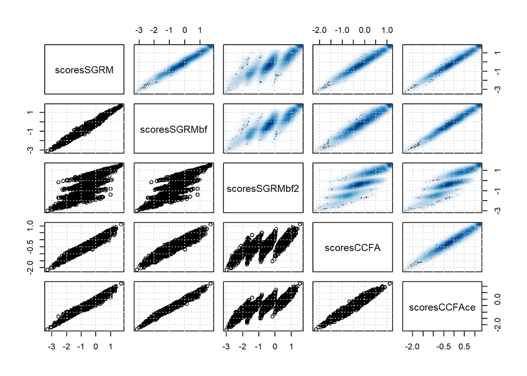

```r
pairs(teachers[, c("scoresSGRM", "scoresSGRMbf", "scoresSGRMbf2",
                   "scoresCCFA", "scoresCCFAce")],
      lower.panel = function(x, y) {
        points(x, y)
        grid()},
      upper.panel = function(x, y) {
        smoothScatter(x, y, add = TRUE)
        grid()})
```